# Assignment3

Tianran Zhang

7/7/2020

# 1.

## Data Description

We have data on tumor volume (cm3) for a newly classified prostate cancer. The tumors have been detected at an early stage.  
Correct the variable type and check for missing values:

```r
TVolume <- read.csv("TVolume.csv")
TVolume <- clean_names(TVolume)

TVolume$subject <- as.factor(TVolume$subject)
TVolume$time_months <- as.factor(TVolume$time_months)

str(TVolume)
```

```
## 'data.frame':    448 obs. of  3 variables:
##  $ subject     : Factor w/ 112 levels "1","2","3","4",..: 1 1 1 1 2 2 2 2 3 3 ...
##  $ tumor_volume: num  0.44 0.43 0.43 0.44 0.48 0.48 0.49 0.51 0.48 0.48 ...
##  $ time_months : Factor w/ 4 levels "1","2","3","4": 1 2 3 4 1 2 3 4 1 2 ...
```

```r
sum(is.na(TVolume))
```

```
## [1] 0
```

There is no missing values in our dataset. Now visulize data and check for normality.

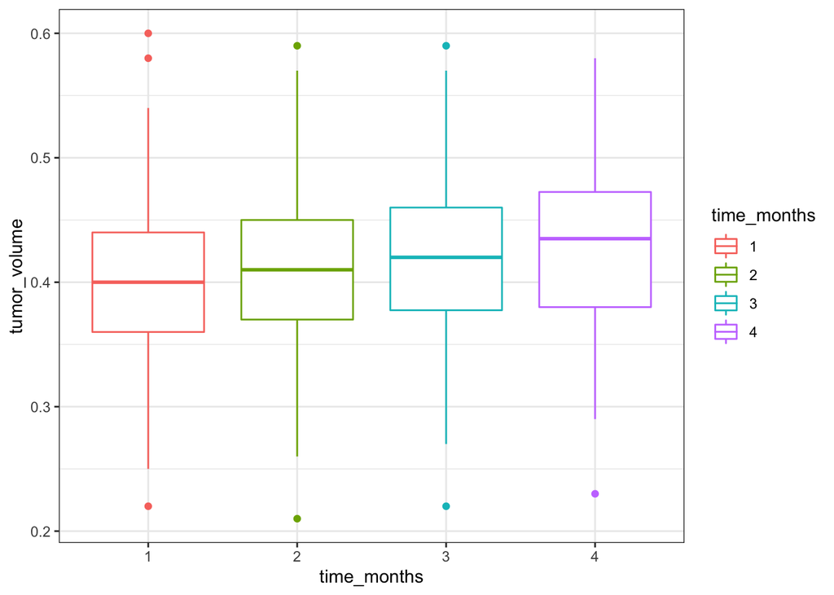

```r
#Visualize data
ggplot(data = TVolume) +
  geom_boxplot(aes(x = time_months, y = tumor_volume, color = time_months)) +
  theme_bw()
```

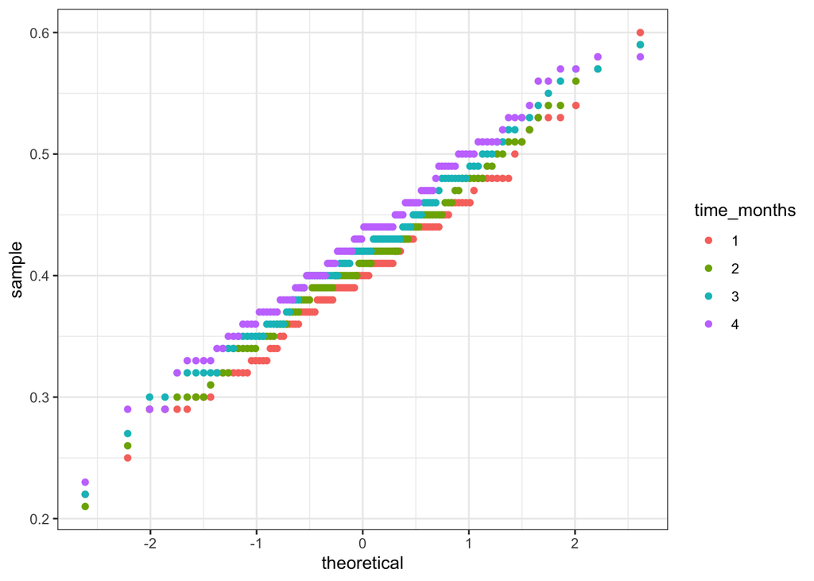

```r
#Normality check
ggplot(TVolume, aes(sample=tumor_volume, color = time_months)) +
  stat_qq() +
  theme_bw()
```

Boxplots show that there is an increasing trend in tumor volume as time increases. Q-Q plot shows that the increasing trend seens to be normal.

## Description of model building

In this study, the outcome of interest (tumor volume) is a continuous variable. We have 4 time points for each subject and one treatment. So, I built a model based on single sample repeated measure ANOVA to investigate if the tumor volume is changing over time.
$$Y_{ij} = \mu + b_i + \tau_i + e_{ij}$$
$Y_{ij} \sim N(\mu + \tau_i, \sigma_b^2 + \sigma_e^2)$: Response for subject i in time j;
$\mu$: Overall mean;
$b_i \sim N(0, \sigma_b^2)$: Random effect of subject i;
$\tau_j, \ \sum_{j = 1}^T\tau_j = 0$: Effect of time j;
$e_{ij}\sim N(0, \sigma_e^2)$: Error term.

## Description of Analysis

Fit the model described above and take a look at the summary:

```r
model1 <- aov(tumor_volume ~ time_months + Error(subject), data = TVolume)
summary(model1)
```

```
##
## Error: subject
##            Df Sum Sq Mean Sq F value Pr(>F)
## Residuals 111  2.019 0.01819
##
## Error: Within
##              Df  Sum Sq  Mean Sq F value Pr(>F)
## time_months   3 0.05397 0.017990     181 <2e-16 ***
## Residuals   333 0.03310 0.000099
## ---
## Signif. codes:  0 '***' 0.001 '**' 0.01 '*' 0.05 '.' 0.1 ' ' 1
```

There is sufficient evidence that the tumor volume is changing over time (p < 0.001). Next, I will investigate if there is a polynomial trend (a combination of linear trend, quadratic trend, and cubic trend) in tumor volume change using contrasts.  
Check the contrasts:

```r
l_cont <- c(-3,-1,1,3)
q_cont <- c(1,-1,-1,1)
c_cont <- c(-1,3,-3,1)

mat <- cbind(l_cont, q_cont, c_cont)

contrasts(TVolume$time_months) <- mat

#Double check contrasts
contrasts(TVolume$time_months)
```

```
##   l_cont q_cont c_cont
## 1     -3      1     -1
## 2     -1     -1      3
## 3      1     -1     -3
## 4      3      1      1
```

Investigate if there is any polynomial trend in tumor volume change:

```r
#Model
model1 <- aov(tumor_volume ~ time_months + Error(subject), data = TVolume)
summary(model1,
        split = list(time_months = list("Linear" = 1,
                                       "Quadratic" = 2,
                                       "Cubic" = 3)))
```

```
##
## Error: subject
##            Df Sum Sq Mean Sq F value Pr(>F)
## Residuals 111  2.019 0.01819
##
## Error: Within
##                           Df  Sum Sq Mean Sq F value Pr(>F)
## time_months                3 0.05397 0.01799 180.962 <2e-16 ***
##   time_months: Linear      1 0.05392 0.05392 542.378 <2e-16 ***
##   time_months: Quadratic   1 0.00004 0.00004   0.379  0.538
##   time_months: Cubic       1 0.00001 0.00001   0.130  0.719
## Residuals                333 0.03310 0.00010
## ---
## Signif. codes:  0 '***' 0.001 '**' 0.01 '*' 0.05 '.' 0.1 ' ' 1
```

Sufficient evidence suggests that tumor size change with a linear trend over time (p < 0.001). However, there is no enough evidence for a quadratic or cubic trend of tumor size changing over time.

## Conclusion

Single sampl repeated measure ANOVA-based analysis showed significant evidence that tumor volume is changing over time. Furthermore, it appears the tumor volume increases with a linear trend as time increases.

# 2.

## Data Description

A novel ghrelin increasing treatment is being tested in patients with abnormally low serum ghrelin. The patients were divided into two groups; one group received the treatment for four days, and the other received placebo. They were observed for the four days, and their serum ghrelin levels (pmol/liter) were recorded.  
Load the data and correct the data type. Check if there is any missing values.

```r
Ghrelin3 <- read.csv("Ghrelin3.csv")
Ghrelin3 <- clean_names(Ghrelin3)

Ghrelin3$subject <- as.factor(Ghrelin3$subject)
Ghrelin3$time_days <- as.factor(Ghrelin3$time_days)

str(Ghrelin3)
```

```
## 'data.frame':    448 obs. of  4 variables:
##  $ subject  : Factor w/ 112 levels "1","2","3","4",..: 1 1 1 1 2 2 2 2 3 3 ...
##  $ ghrelin  : num  165 150 NA 178 170 ...
##  $ time_days: Factor w/ 4 levels "1","2","3","4": 1 2 3 4 1 2 3 4 1 2 ...
##  $ treatment: chr  "Treatment" "Treatment" "Treatment" "Treatment" ...
```

```r
sum(is.na(Ghrelin3))
```

```
## [1] 39
```

It appears there is 39 missing values in our dataset. I conducted 10 imputations for missing data with predictive mean matching method.

```r
set.seed(135)
mice_1 <- mice(data= Ghrelin3, #dataset
               m = 10, #Number of multiple imputations
               method = "pmm",#Predictive mean matching
               printFlag = F)

summary(mice_1)
```

```
## Class: mids
## Number of multiple imputations:  10
## Imputation methods:
##   subject   ghrelin time_days treatment
##        ""     "pmm"        ""        ""
## PredictorMatrix:
##           subject ghrelin time_days treatment
## subject         0       1         1         0
## ghrelin         1       0         1         0
## time_days       1       1         0         0
## treatment       1       1         1         0
## Number of logged events:  1
##   it im dep     meth       out
## 1  0  0     constant treatment
```

## Description of model building

In this study, the outcome of interest (the novel ghrelin) is a continuous variable. We have 4 time points and 2 sample groups. So, I bulit a model based on multiple sample repeated measure ANOVA to test if the treatment is efficacious.
$$Y_{ijk} = \mu + \delta_i + \tau_j + b_i(k) + (\delta\tau)_{ij} + e_{ijk}$$
$Y_{ijk} \sim N(\mu + \delta_i + \tau_j + (\delta\tau)_{ij}, \sigma_b^2 + \sigma_e^2)$: Response for subject k in time j in group i;
$\mu$: Overall mean;
$\delta_i, \ \sum_{i = 1}^G\delta_i = 0$: Effect of group i;
$\tau_j, \ \sum_{j = 1}^T\tau_j = 0$: Effect of time j;
$b_{i(k)} \sim N(0, \sigma_b^2)$: Random effect of subject k nested within group i;
$(\delta\tau)_{ij}, \ \sum_{i = 1}^G\sum_{j = 1}^T(\delta\tau)_{ij} = 0$: Interaction effect of group & time;
$e_{ijk} \sim N(0, \sigma_e^2)$: Error term.

## Description of data analysis

Fit the model in all 10 imputed datasets. Combine the 10 results and find average mean squared values. Calculate the F-statistics and the corresponding p-values:

```r
# Fit the model in all 10 imputed datasets.
fit1 <- with(data = mice_1, exp = aov(ghrelin ~ (time_days * treatment) +
                                        Error(subject)))
df1 <- as.data.frame(summary(fit1))

# Combine the results over all 10 imputed datasets and find average mean squared values

#Treatment
avg_meansq_tx <- df1 %>%
  filter(term == 'treatment') %>%
  summarize(mean = mean(meansq))

avg_meansq_residuals_1 <- df1 %>%
  filter(term == 'Residuals' & stratum == 'subject') %>%
  summarize(mean = mean(meansq))

#Timepoint
avg_meansq_tp <- df1 %>%
  filter(term == 'time_days') %>%
  summarize(mean = mean(meansq))

avg_meansq_residuals_2 <- df1 %>%
  filter(term == 'Residuals' & stratum == 'Within') %>%
  summarize(mean = mean(meansq))

#Interaction Between Timepoint + Treatment
avg_meansq_tx_tp <- df1 %>%
  filter(term == 'time_days:treatment') %>%
  summarize(mean = mean(meansq))

# Calculate F-Statistic
f_tx <- as.numeric(avg_meansq_tx/avg_meansq_residuals_1)
f_tp <- as.numeric(avg_meansq_tp/avg_meansq_residuals_2)
f_txtp <- as.numeric(avg_meansq_tx_tp/avg_meansq_residuals_2)

#Calculate p-values
ans <- data.frame(1 - pf(f_tx, 1, 110),
                  1 - pf(f_tp, 3, 330),
                  1 - pf(f_txtp, 3, 330))

colnames(ans) = c("treatment", "time_days", "treatment:time_days")
ans %>%
  kable() %>%
  kable_styling()
```

| treatment | time_days | treatment:time_days |
| --- | --- | --- |
| 0.5050055 | 0.2747396 | 0.6439927 |